# METABRIC Breast Cancer Survival Analysis

## Overview

This analysis uses the METABRIC (Molecular Taxonomy of Breast Cancer International Consortium) dataset to look at overall survival in breast cancer patients. The dataset has 2,509 patients with 34 clinical and molecular variables. The goal here is to first describe survival patterns using Kaplan-Meier curves, then model the effect of key clinical predictors using Cox proportional hazards regression.

## Loading the Data

```r
library(tidyverse)
library(survival)
library(survminer)

# Importing the dataset for analysis
metabric <- read_csv("Breast Cancer METABRIC.csv")

colnames(metabric)
```

```
##  [1] "Patient ID"                     "Age at Diagnosis"
##  [3] "Type of Breast Surgery"         "Cancer Type"
##  [5] "Cancer Type Detailed"           "Cellularity"
##  [7] "Chemotherapy"                   "Pam50 + Claudin-low subtype"
##  [9] "Cohort"                         "ER status measured by IHC"
## [11] "ER Status"                      "Neoplasm Histologic Grade"
## [13] "HER2 status measured by SNP6"   "HER2 Status"
## [15] "Tumor Other Histologic Subtype" "Hormone Therapy"
## [17] "Inferred Menopausal State"      "Integrative Cluster"
## [19] "Primary Tumor Laterality"       "Lymph nodes examined positive"
## [21] "Mutation Count"                 "Nottingham prognostic index"
## [23] "Oncotree Code"                  "Overall Survival (Months)"
## [25] "Overall Survival Status"        "PR Status"
## [27] "Radio Therapy"                  "Relapse Free Status (Months)"
## [29] "Relapse Free Status"            "Sex"
## [31] "3-Gene classifier subtype"      "Tumor Size"
## [33] "Tumor Stage"                    "Patient's Vital Status"
```

The dataset comes in with 34 columns covering patient demographics, tumor characteristics, treatment history, and survival outcomes. The key variables we’ll be using are overall survival time, survival status, tumor stage, grade, size, and receptor statuses (ER, PR, HER2).

## Exploratory Data Check

```r
# Inspecting the structure of our dataset
str(metabric)
```

```
## spc_tbl_ [2,509 × 34] (S3: spec_tbl_df/tbl_df/tbl/data.frame)
##  $ Patient ID                    : chr [1:2509] "MB-0000" "MB-0002" "MB-0005" "MB-0006" ...
##  $ Age at Diagnosis              : num [1:2509] 75.7 43.2 48.9 47.7 77 ...
##  $ Type of Breast Surgery        : chr [1:2509] "Mastectomy" "Breast Conserving" "Mastectomy" "Mastectomy" ...
##  $ Cancer Type                   : chr [1:2509] "Breast Cancer" "Breast Cancer" "Breast Cancer" "Breast Cancer" ...
##  $ Cancer Type Detailed          : chr [1:2509] "Breast Invasive Ductal Carcinoma" "Breast Invasive Ductal Carcinoma" "Breast Invasive Ductal Carcinoma" "Breast Mixed Ductal and Lobular Carcinoma" ...
##  $ Cellularity                   : chr [1:2509] NA "High" "High" "Moderate" ...
##  $ Chemotherapy                  : chr [1:2509] "No" "No" "Yes" "Yes" ...
##  $ Pam50 + Claudin-low subtype   : chr [1:2509] "claudin-low" "LumA" "LumB" "LumB" ...
##  $ Cohort                        : num [1:2509] 1 1 1 1 1 1 1 1 1 1 ...
##  $ ER status measured by IHC     : chr [1:2509] "Positve" "Positve" "Positve" "Positve" ...
##  $ ER Status                     : chr [1:2509] "Positive" "Positive" "Positive" "Positive" ...
##  $ Neoplasm Histologic Grade     : num [1:2509] 3 3 2 2 3 3 2 3 2 3 ...
##  $ HER2 status measured by SNP6  : chr [1:2509] "Neutral" "Neutral" "Neutral" "Neutral" ...
##  $ HER2 Status                   : chr [1:2509] "Negative" "Negative" "Negative" "Negative" ...
##  $ Tumor Other Histologic Subtype: chr [1:2509] "Ductal/NST" "Ductal/NST" "Ductal/NST" "Mixed" ...
##  $ Hormone Therapy               : chr [1:2509] "Yes" "Yes" "Yes" "Yes" ...
##  $ Inferred Menopausal State     : chr [1:2509] "Post" "Pre" "Pre" "Pre" ...
##  $ Integrative Cluster           : chr [1:2509] "4ER+" "4ER+" "3" "9" ...
##  $ Primary Tumor Laterality      : chr [1:2509] "Right" "Right" "Right" "Right" ...
##  $ Lymph nodes examined positive : num [1:2509] 10 0 1 3 8 0 1 NA 1 11 ...
##  $ Mutation Count                : num [1:2509] NA 2 2 1 2 4 4 NA 1 5 ...
##  $ Nottingham prognostic index   : num [1:2509] 6.04 4.02 4.03 4.05 6.08 ...
##  $ Oncotree Code                 : chr [1:2509] "IDC" "IDC" "IDC" "MDLC" ...
##  $ Overall Survival (Months)     : num [1:2509] 140.5 84.6 163.7 164.9 41.4 ...
##  $ Overall Survival Status       : chr [1:2509] "Living" "Living" "Deceased" "Living" ...
##  $ PR Status                     : chr [1:2509] "Negative" "Positive" "Positive" "Positive" ...
##  $ Radio Therapy                 : chr [1:2509] "Yes" "Yes" "No" "Yes" ...
##  $ Relapse Free Status (Months)  : num [1:2509] 138.7 83.5 151.3 162.8 18.6 ...
##  $ Relapse Free Status           : chr [1:2509] "Not Recurred" "Not Recurred" "Recurred" "Not Recurred" ...
##  $ Sex                           : chr [1:2509] "Female" "Female" "Female" "Female" ...
##  $ 3-Gene classifier subtype     : chr [1:2509] "ER-/HER2-" "ER+/HER2- High Prolif" NA NA ...
##  $ Tumor Size                    : num [1:2509] 22 10 15 25 40 31 10 65 29 34 ...
##  $ Tumor Stage                   : num [1:2509] 2 1 2 2 2 4 2 3 2 2 ...
##  $ Patient's Vital Status        : chr [1:2509] "Living" "Living" "Died of Disease" "Living" ...
##  - attr(*, "spec")=
##   .. cols(
##   ..   `Patient ID` = col_character(),
##   ..   `Age at Diagnosis` = col_double(),
##   ..   `Type of Breast Surgery` = col_character(),
```

[output cut: 18 more lines]

```
##   ..   `Nottingham prognostic index` = col_double(),
##   ..   `Oncotree Code` = col_character(),
##   ..   `Overall Survival (Months)` = col_double(),
##   ..   `Overall Survival Status` = col_character(),
##   ..   `PR Status` = col_character(),
##   ..   `Radio Therapy` = col_character(),
##   ..   `Relapse Free Status (Months)` = col_double(),
##   ..   `Relapse Free Status` = col_character(),
##   ..   Sex = col_character(),
##   ..   `3-Gene classifier subtype` = col_character(),
##   ..   `Tumor Size` = col_double(),
##   ..   `Tumor Stage` = col_double(),
##   ..   `Patient's Vital Status` = col_character()
##   .. )
##  - attr(*, "problems")=<externalptr>
```

```r
# Quick summary of the dataset
summary(metabric)
```

```
##   Patient ID        Age at Diagnosis Type of Breast Surgery Cancer Type
##  Length:2509        Min.   :21.93    Length:2509            Length:2509
##  Class :character   1st Qu.:50.92    Class :character       Class :character
##  Mode  :character   Median :61.11    Mode  :character       Mode  :character
##                     Mean   :60.42
##                     3rd Qu.:70.00
##                     Max.   :96.29
##                     NA's   :11
##  Cancer Type Detailed Cellularity        Chemotherapy
##  Length:2509          Length:2509        Length:2509
##  Class :character     Class :character   Class :character
##  Mode  :character     Mode  :character   Mode  :character
##
##
##
##
##  Pam50 + Claudin-low subtype     Cohort    ER status measured by IHC
##  Length:2509                 Min.   :1.0   Length:2509
##  Class :character            1st Qu.:1.0   Class :character
##  Mode  :character            Median :3.0   Mode  :character
##                              Mean   :2.9
##                              3rd Qu.:4.0
##                              Max.   :9.0
##                              NA's   :11
##   ER Status         Neoplasm Histologic Grade HER2 status measured by SNP6
##  Length:2509        Min.   :1.000             Length:2509
##  Class :character   1st Qu.:2.000             Class :character
##  Mode  :character   Median :3.000             Mode  :character
##                     Mean   :2.412
##                     3rd Qu.:3.000
##                     Max.   :3.000
##                     NA's   :121
##  HER2 Status        Tumor Other Histologic Subtype Hormone Therapy
##  Length:2509        Length:2509                    Length:2509
##  Class :character   Class :character               Class :character
##  Mode  :character   Mode  :character               Mode  :character
##
##
##
##
```

[output cut: 33 more lines]

```
##  Length:2509         Length:2509        Length:2509
##  Class :character    Class :character   Class :character
##  Mode  :character    Mode  :character   Mode  :character
##
##
##
##
##    Tumor Size      Tumor Stage    Patient's Vital Status
##  Min.   :  1.00   Min.   :0.000   Length:2509
##  1st Qu.: 17.00   1st Qu.:1.000   Class :character
##  Median : 22.41   Median :2.000   Mode  :character
##  Mean   : 26.22   Mean   :1.714
##  3rd Qu.: 30.00   3rd Qu.:2.000
##  Max.   :182.00   Max.   :4.000
##  NA's   :149      NA's   :721
```

A quick look at the structure shows a mix of numeric and character columns. Worth noting that several key variables have missing data — `Overall Survival (Months)` and `Overall Survival Status` each have 528 missing values, and `Tumor Stage` has 721. We’ll handle these in the cleaning step.

## Data Cleaning

```r
# Cleaning the dataset for analysis
metabric_clean <- metabric %>%
  rename(
    time_raw = `Overall Survival (Months)`,
    status_raw = `Overall Survival Status`,
    age = `Age at Diagnosis`,
    stage = `Tumor Stage`,
    size = `Tumor Size`,
    grade = `Neoplasm Histologic Grade`,
    ER = `ER Status`,
    PR = `PR Status`,
    HER2 = `HER2 Status`
  ) %>%
  filter(
    !is.na(time_raw),
    !is.na(status_raw),
    !is.na(stage),
    time_raw > 0
  ) %>%
  mutate(
    time = time_raw,
    event = ifelse(status_raw == "Deceased", 1, 0),
    stage = factor(stage),
    grade = factor(grade),
    ER = factor(ER),
    PR = factor(PR),
    HER2 = factor(HER2)
  ) %>%
  select(time, event, age, stage, size, grade, ER, PR, HER2)

dim(metabric_clean)
```

```
## [1] 1466    9
```

```r
table(metabric_clean$event) %>%
  as.data.frame() %>%
  rename(Event = Var1, Count = Freq) %>%
  kable(caption = "Event Distribution (0 = Alive, 1 = Deceased)") %>%
  kable_styling(bootstrap_options = c("striped", "hover", "condensed"), full_width = FALSE)
```

Event Distribution (0 = Alive, 1 = Deceased)

| Event | Count |
| --- | --- |
| 0 | 643 |
| 1 | 823 |

```r
table(metabric_clean$stage, useNA = "always") %>%
  as.data.frame() %>%
  rename(Stage = Var1, Count = Freq) %>%
  kable(caption = "Tumor Stage Distribution") %>%
  kable_styling(bootstrap_options = c("striped", "hover", "condensed"), full_width = FALSE)
```

Tumor Stage Distribution

| Stage | Count |
| --- | --- |
| 0 | 12 |
| 1 | 501 |
| 2 | 825 |
| 3 | 118 |
| 4 | 10 |
| NA | 0 |

After filtering out rows with missing survival time, survival status, or tumor stage, we’re left with **1,466 patients** — down from 2,509. That’s a meaningful reduction, mostly driven by the 721 missing tumor stage values. It’s worth keeping in mind that this missingness isn’t necessarily random and could introduce some selection bias.

The stage distribution in the cleaned dataset skews heavily toward Stage II (825 patients), with Stage IV being quite small (only 10 patients). A few patients are coded as Stage 0, which we’ll exclude from the stage-specific analysis since it’s not really comparable to the invasive stages.

Also note that while PR and HER2 have no missing values in the cleaned subset, tumor size is missing for 7 patients and grade for 58. These rows will be silently dropped when we run the Cox model, so the effective sample size there will be slightly smaller.

## Kaplan-Meier: Overall Survival

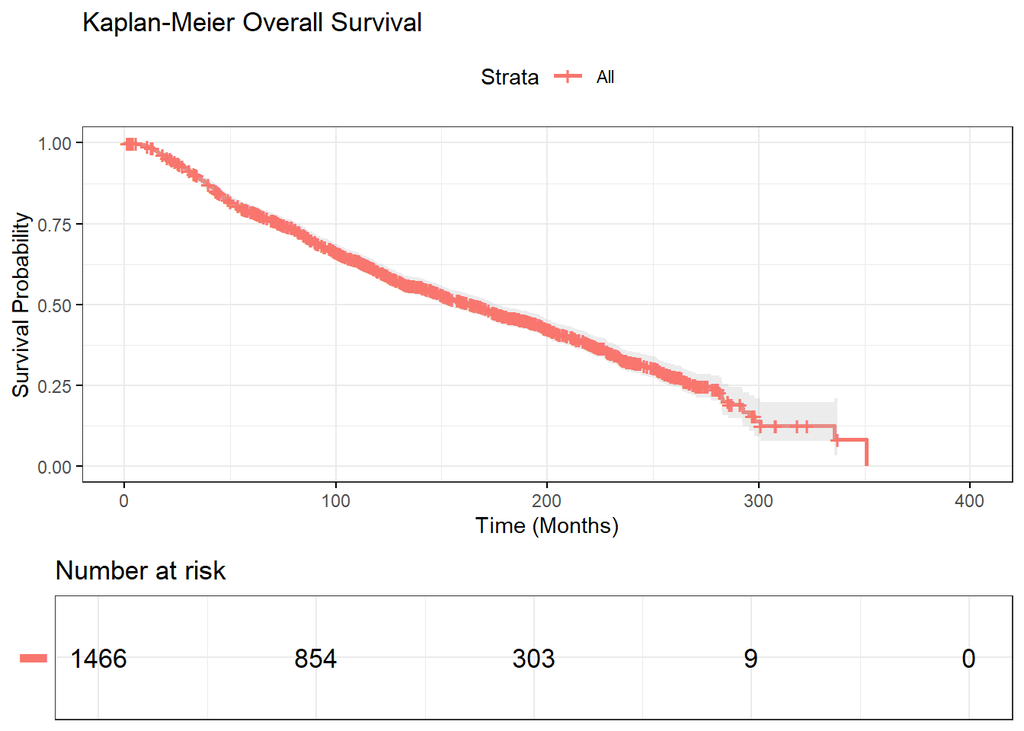

```r
# Overall Kaplan-Meier
km_overall <- survfit(Surv(time, event) ~ 1, data = metabric_clean)

ggsurvplot(
  km_overall,
  data = metabric_clean,
  conf.int = TRUE,
  risk.table = TRUE,
  risk.table.y.text = FALSE,
  risk.table.height = 0.25,
  tables.theme = theme_cleantable(),
  xlab = "Time (Months)",
  ylab = "Survival Probability",
  title = "Kaplan-Meier Overall Survival",
  ggtheme = theme_bw(),
  tables.ggtheme = theme_bw()
)
```

The overall KM curve gives a baseline picture of survival across all 1,466 patients. The shaded region is the 95% confidence interval, and the risk table below the plot shows how many patients remain under observation at each time point. The curve drops fairly steadily over time, and the widening confidence interval toward the right reflects fewer patients remaining at risk in later follow-up.

## Kaplan-Meier: Survival by Tumor Stage

```r
# Stage-specific Kaplan-Meier — excluding Stage 0 since it's not comparable to invasive stages
metabric_stage <- metabric_clean %>%
  filter(!is.na(stage), stage != "0") %>%
  mutate(stage = droplevels(stage))

# Confirm stage counts before plotting
table(metabric_stage$stage)
```

```
##
##   1   2   3   4
## 501 825 118  10
```

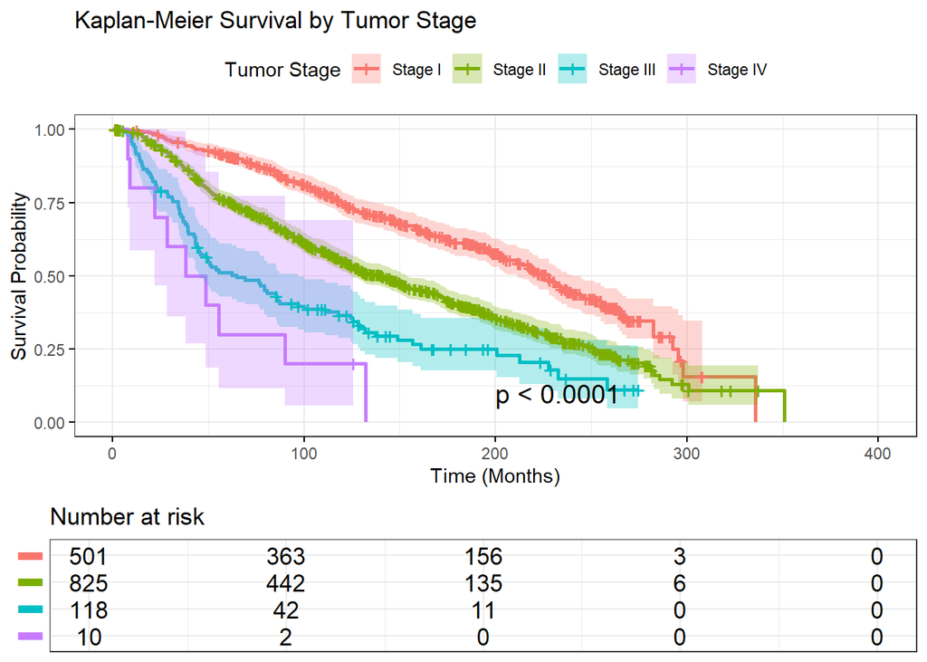

```r
km_stage <- survfit(Surv(time, event) ~ stage, data = metabric_stage)

# Dynamically generate stage labels based on remaining levels
stage_levels <- levels(metabric_stage$stage)
stage_labels <- paste("Stage", as.roman(as.integer(stage_levels)))

ggsurvplot(km_stage,
           data = metabric_stage,
           conf.int = TRUE,
           risk.table = TRUE,
           risk.table.y.text = FALSE,
           risk.table.height = 0.25,
           tables.theme = theme_cleantable(),
           pval = TRUE,
           pval.coord = c(200, 0.1),
           legend.title = "Tumor Stage",
           legend.labs = stage_labels,
           xlab = "Time (Months)",
           ylab = "Survival Probability",
           title = "Kaplan-Meier Survival by Tumor Stage",
           ggtheme = theme_bw(),
           tables.ggtheme = theme_bw())
```

As expected, survival probability decreases with higher tumor stage. Stage I patients have the best outcomes, while Stage IV patients have a noticeably steeper decline early on. The log-rank p-value confirms that the differences between stages are statistically significant.

One thing to keep in mind with Stage IV is the very small sample size (only 10 patients after cleaning), so the curve for that group should be interpreted with caution — the confidence intervals would be wide and the estimates less reliable.

## Cox Proportional Hazards Model

```r
# Running a Cox PH model with key clinical predictors
cox_model <- coxph(Surv(time, event) ~ age + stage + size + grade + ER + PR + HER2,
                   data = metabric_clean)

summary(cox_model)
```

```
## Call:
## coxph(formula = Surv(time, event) ~ age + stage + size + grade +
##     ER + PR + HER2, data = metabric_clean)
##
##   n= 1406, number of events= 785
##    (60 observations deleted due to missingness)
##
##                   coef exp(coef)  se(coef)      z Pr(>|z|)
## age           0.035729  1.036374  0.003241 11.025  < 2e-16 ***
## stage1        0.118364  1.125654  1.011424  0.117  0.90684
## stage2        0.496339  1.642696  1.007638  0.493  0.62231
## stage3        0.739860  2.095643  1.008903  0.733  0.46336
## stage4        1.496073  4.464122  1.058044  1.414  0.15736
## size          0.011135  1.011198  0.002384  4.671    3e-06 ***
## grade2        0.122412  1.130220  0.152557  0.802  0.42232
## grade3        0.268062  1.307428  0.152967  1.752  0.07970 .
## ERPositive   -0.215569  0.806083  0.106040 -2.033  0.04206 *
## PRPositive   -0.042699  0.958200  0.086377 -0.494  0.62107
## HER2Positive  0.417425  1.518047  0.109593  3.809  0.00014 ***
## ---
## Signif. codes:  0 '***' 0.001 '**' 0.01 '*' 0.05 '.' 0.1 ' ' 1
##
##              exp(coef) exp(-coef) lower .95 upper .95
## age             1.0364     0.9649    1.0298    1.0430
## stage1          1.1257     0.8884    0.1551    8.1720
## stage2          1.6427     0.6088    0.2280   11.8375
## stage3          2.0956     0.4772    0.2901   15.1390
## stage4          4.4641     0.2240    0.5612   35.5095
## size            1.0112     0.9889    1.0065    1.0159
## grade2          1.1302     0.8848    0.8381    1.5241
## grade3          1.3074     0.7649    0.9688    1.7645
## ERPositive      0.8061     1.2406    0.6548    0.9923
## PRPositive      0.9582     1.0436    0.8090    1.1350
## HER2Positive    1.5180     0.6587    1.2246    1.8818
##
## Concordance= 0.664  (se = 0.011 )
## Likelihood ratio test= 275.7  on 11 df,   p=<2e-16
## Wald test            = 282.8  on 11 df,   p=<2e-16
## Score (logrank) test = 297.9  on 11 df,   p=<2e-16
```

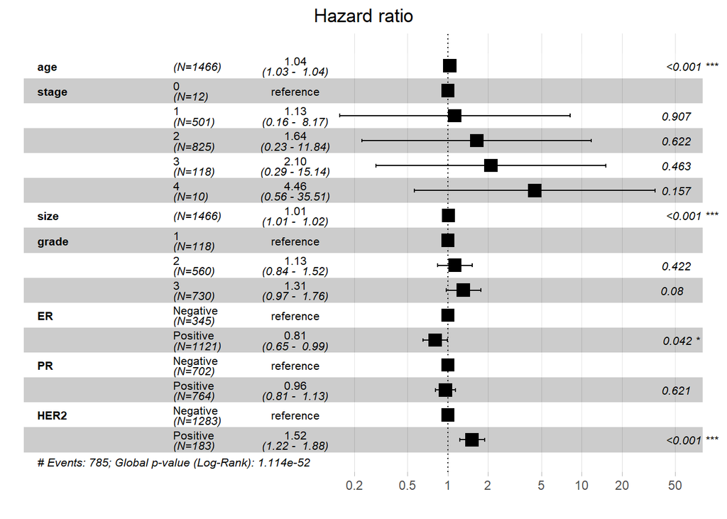

```r
# Visualizing the Cox model results
metabric_clean_df <- as.data.frame(metabric_clean)

ggforest(cox_model, data = metabric_clean_df)
```

The Cox model estimates the effect of each predictor on hazard (risk of death) while adjusting for the others. Hazard ratios (HR) above 1 indicate increased risk, below 1 indicate reduced risk. The forest plot makes it easy to see which variables have the strongest effects and whether their confidence intervals cross 1 (no effect).

A few things to note here: the model loses a few more rows due to missing tumor size and grade values, so the actual n used in fitting is slightly lower than 1,466. This is standard behavior in R’s `coxph()` — it uses complete cases by default.

## Testing the Proportional Hazards Assumption

```r
# Testing the proportional hazards assumption
cox_zph_test <- cox.zph(cox_model)
print(cox_zph_test)  # Smaller p-values suggest evidence against the PH assumption
```

```
##          chisq df       p
## age     67.262  1 2.4e-16
## stage   25.386  4 4.2e-05
## size     0.995  1 0.31861
## grade   45.009  2 1.7e-10
## ER      61.320  1 4.9e-15
## PR      30.504  1 3.3e-08
## HER2    11.544  1 0.00068
## GLOBAL 140.783 11 < 2e-16
```

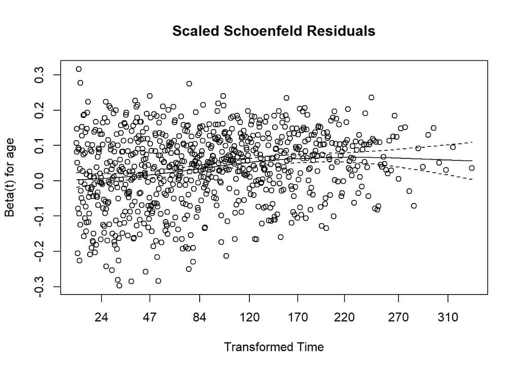

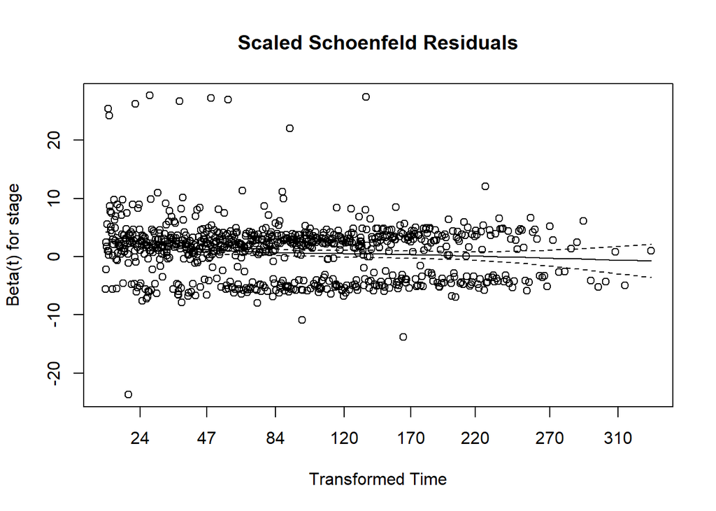

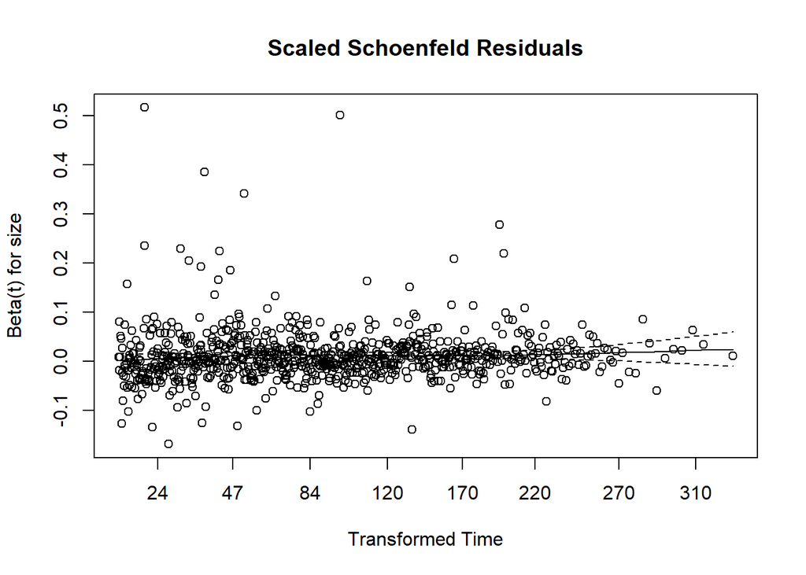

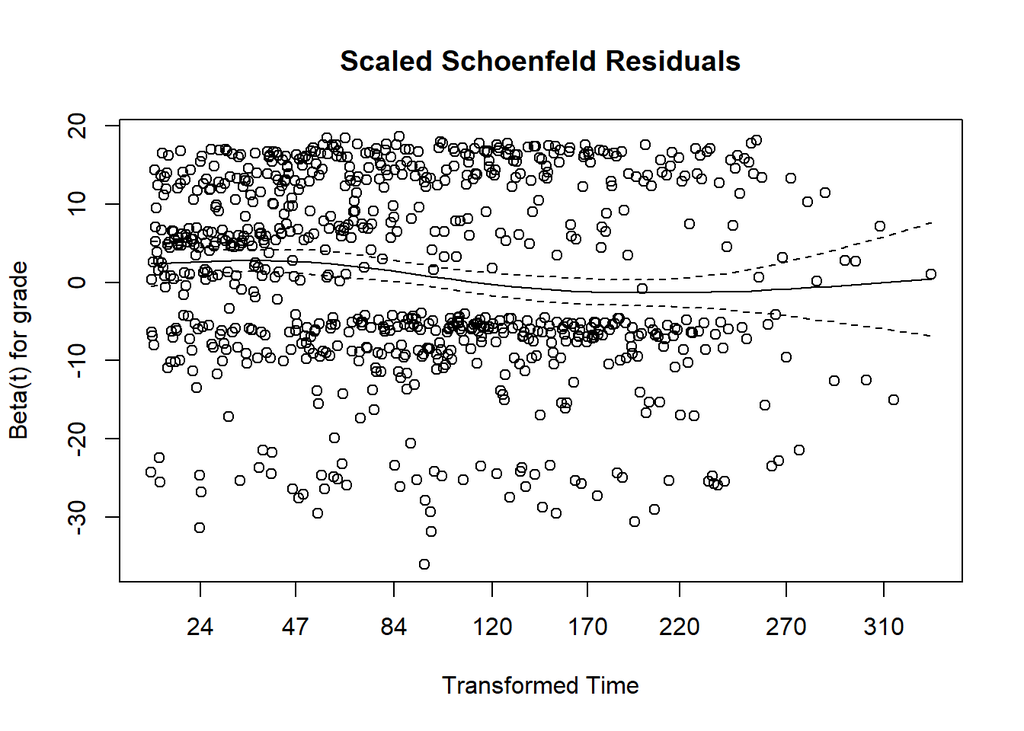

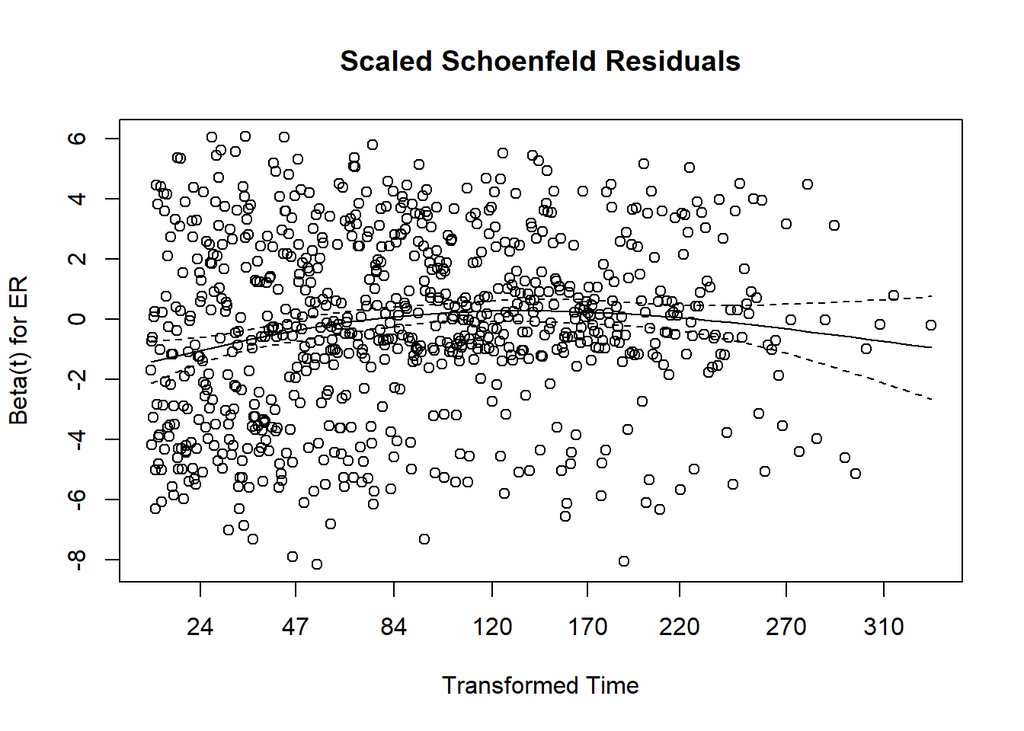

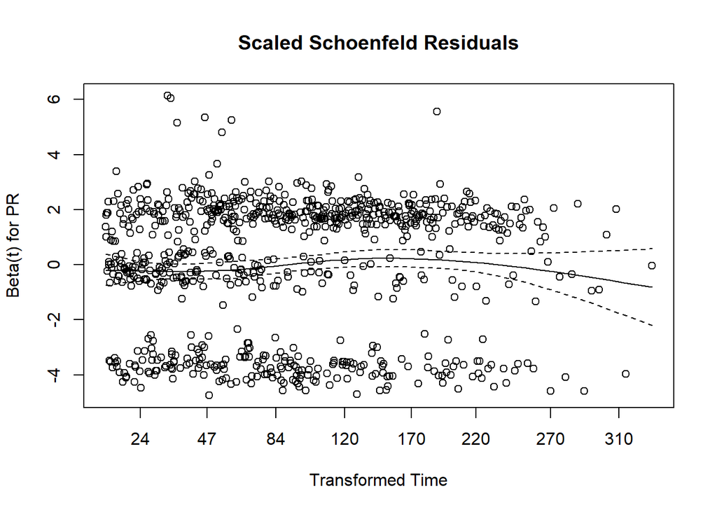

```r
# Plotting residuals (straight lines = assumption holds)
plot(cox_zph_test,
     main = "Scaled Schoenfeld Residuals",
     xlab = "Transformed Time")
```

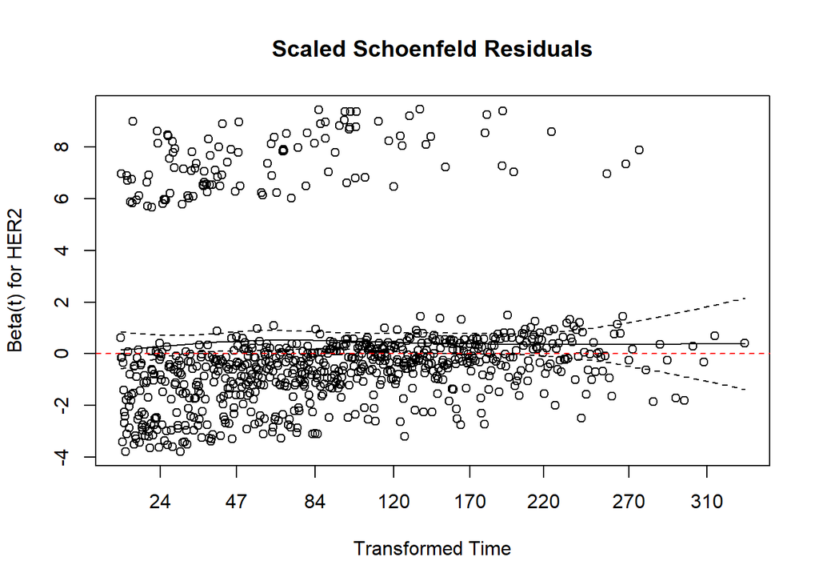

```r
abline(h = 0, col = "red", lty = 2)
```

The proportional hazards assumption requires that the effect of each predictor stays constant over time. We test this using scaled Schoenfeld residuals — if the residuals trend over time, it’s a sign the assumption is violated.

Any variables with a significant p-value in the `cox.zph()` output are flagging potential violations. This is what motivates the revised model below.

## Revised Cox Model (Addressing PH Violations)

```r
# Revised Cox model addressing PH violations:
# - stage is handled with stratification (removes it from the hazard equation but adjusts for it)
# - age is modeled as a time-dependent covariate using tt(), allowing its effect to change over time
cox_revised <- coxph(
  Surv(time, event) ~ age + tt(age) + size + grade + ER + PR + HER2 + strata(stage),
  data = metabric_clean,
  tt = function(x, t, ...) x * log(t + 1)
)

summary(cox_revised)
```

```
## Call:
## coxph(formula = Surv(time, event) ~ age + tt(age) + size + grade +
##     ER + PR + HER2 + strata(stage), data = metabric_clean, tt = function(x,
##     t, ...) x * log(t + 1))
##
##   n= 1406, number of events= 785
##    (60 observations deleted due to missingness)
##
##                   coef exp(coef)  se(coef)      z Pr(>|z|)
## age          -0.082142  0.921142  0.015776 -5.207 1.92e-07 ***
## tt(age)       0.028057  1.028454  0.003723  7.536 4.84e-14 ***
## size          0.010188  1.010240  0.002427  4.197 2.70e-05 ***
## grade2        0.123170  1.131077  0.152620  0.807 0.419645
## grade3        0.259656  1.296483  0.153143  1.696 0.089980 .
## ERPositive   -0.211206  0.809608  0.106224 -1.988 0.046777 *
## PRPositive   -0.060093  0.941677  0.086478 -0.695 0.487118
## HER2Positive  0.390645  1.477934  0.110416  3.538 0.000403 ***
## ---
## Signif. codes:  0 '***' 0.001 '**' 0.01 '*' 0.05 '.' 0.1 ' ' 1
##
##              exp(coef) exp(-coef) lower .95 upper .95
## age             0.9211     1.0856    0.8931    0.9501
## tt(age)         1.0285     0.9723    1.0210    1.0360
## size            1.0102     0.9899    1.0054    1.0151
## grade2          1.1311     0.8841    0.8387    1.5255
## grade3          1.2965     0.7713    0.9603    1.7503
## ERPositive      0.8096     1.2352    0.6574    0.9970
## PRPositive      0.9417     1.0619    0.7949    1.1156
## HER2Positive    1.4779     0.6766    1.1903    1.8350
##
## Concordance= 0.647  (se = 0.012 )
## Likelihood ratio test= 220.6  on 8 df,   p=<2e-16
## Wald test            = 208.6  on 8 df,   p=<2e-16
## Score (logrank) test = 216.7  on 8 df,   p=<2e-16
```

```r
# Note: cox.zph() cannot be used on this model because tt() terms are not
# compatible with the standard Schoenfeld residual test
```

For the revised model, two changes were made to address the PH violations identified above:

**Stage** was handled using stratification (`strata(stage)`). This means stage is no longer estimated as a single hazard ratio — instead, the model fits a separate baseline hazard for each stage. This is a common approach when a variable violates PH but you still want to adjust for it.

**Age** was modeled as a time-dependent covariate using `tt()`, with the interaction term `age * log(t + 1)`. This lets the effect of age on hazard change as a function of follow-up time, rather than assuming it stays constant throughout.

The trade-off is that this revised model is harder to interpret directly — particularly for stage, since we no longer get a single HR for it. But it gives us more honest estimates for the remaining predictors.